# Data Science or Computer Science?

# Analysis

## Hypothesis

NOTE: If you’re unfamiliar with mathematical notation, hover over the specific parts of the hypothesis to see an explanation. Hovering over $H_0$ or $H_a$ lets you see the hypothesis in simple text.

1. Does occupation type between Data Science and Computer Science affect Salary? Factor: Occupation with levels DS and CS.

$H_0$: $\mu_{DS}$ = $\mu_{CS}$ = $\mu$

$H_a$: $\mu_{DS}$ ≠ $\mu_{CS}$

2. Does seniority level affect salary? Factor: Seniority Level with Levels E, M, S (Entry Level, Mid Level, Senior Level).

$H_0$ : $\mu_E$ = $\mu_M$ = $\mu_S$ = $\mu$

$H_a$ : $\mu_i$ ≠ $\mu$ $\text{for at least one } i \in \{E, M, S\}$

$$H_0:\mu_E = \mu_M = \mu_S = \mu$$
$$H_a: \mu_i \neq \mu \text{ for at least one
} i \in {1 = E, 2 = M, 3 = S}$$

3. Does the effect of occupation type between Data Science and Computer Science change for different seniority levels?

$$H_0: \text{The effect seniority level
has on salary is the same for the two occupations.}$$
$$H_a: \text{The effect seniority level has on
salary is not the same for the two occupations}$$

## Two-way ANOVA

```r
salary.aov <- aov(Salary ~ Occupation
                  + Seniority_Level
                  + Occupation:Seniority_Level,
                  data = df1)

summary(salary.aov) %>% pander()
```

Analysis of Variance Model (continued below)

|  | Df | Sum Sq | Mean Sq | F value |
| --- | --- | --- | --- | --- |
| **Occupation** | 1 | 7.462e+11 | 7.462e+11 | 914.4 |
| **Seniority_Level** | 2 | 3.929e+12 | 1.964e+12 | 2407 |
| **Occupation:Seniority_Level** | 2 | 3.823e+10 | 1.912e+10 | 23.42 |
| **Residuals** | 3994 | 3.26e+12 | 816126903 | NA |

|  | Pr(>F) |
| --- | --- |
| **Occupation** | 4.752e-181 |
| **Seniority_Level** | 0 |
| **Occupation:Seniority_Level** | 7.702e-11 |
| **Residuals** | NA |

## Diagnostic Plots

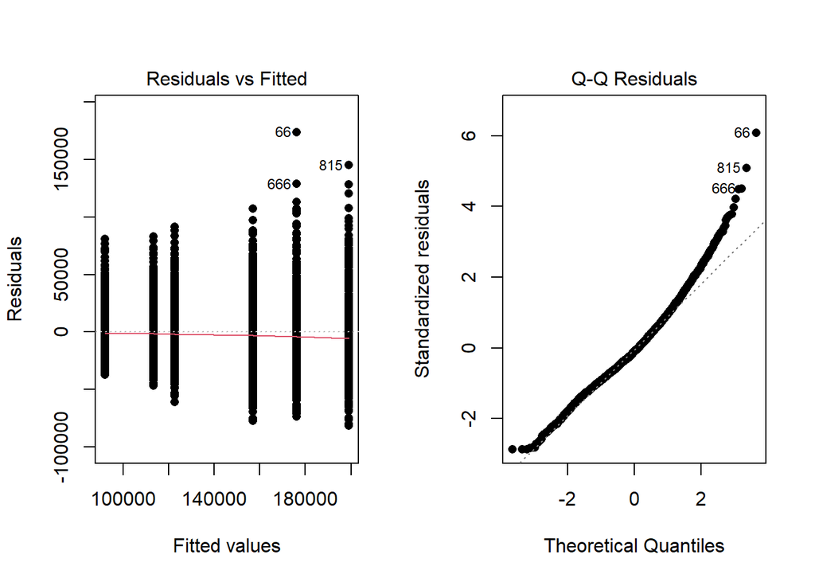

```r
par(mfrow=c(1,2))
plot(salary.aov, which=1:2, pch=16)
```

Both the Residuals vs Fitted Values and Q-Q Residuals plots appear to be questionable. The spread of the 6 sets of points seems to widen as we go along the x axis. The qqPlot is also showing a heavy right skew, which is to be expected for the dataset containing salaries. Although they seem questionable, with a sample size of 4000, CLT allows the results of the test can still be considered valid.